# Movie Ticket PricePrediction

## By Moumita Das

### Problem Statement

With the expansion of OTT platforms like Netflix, Amazon Prime, people prefer to watch content at theirconvenience. Factors like Pricing, Content Quality & Marketing have influenced the success of these platforms. The cost of making a full-length movie has shot up exponentially in the recent past. Only 10% of the movies thatare made make profits. Stiff competition from Television & OTT platforms along with the high ticket cost hasmade it difficult for films to make money even harder. The rising cost of the theatre ticket (along with thepopcorn cost) leaves the cinema hall empty. A movie ticket pricing prediction using Machine Learning can definitely help the movie makers and viewers.Ticket prices can be higher with the rise in demand for tickets and vice versa. The earlier the viewer books theticket, the lesser the cost, for a movie with high demand. Build a Machine Learning model that should smartlycalculate the pricing depending on the interest of the viewers, social signals,supply-demand factors, etc.

```python
import pandas as pd # for reading the file
import numpy as np # for numericals & mathematicals experssion
import seaborn as sns # for data visulization
import matplotlib.pyplot as plt # for data visulization
%matplotlib inline
import time
import warnings
warnings.filterwarnings('ignore')
```

```python
Ticket = pd.read_csv("CinemaTicket.csv")
```

```python
Ticket.head()
```

|  | film_code | cinema_code | total_sales | tickets_sold | tickets_out | show_time | occu_perc | ticket_price | ticket_use | capacity | date | month | quarter | day |
| --- | --- | --- | --- | --- | --- | --- | --- | --- | --- | --- | --- | --- | --- | --- |
| 0 | 1492 | 304 | 3900000 | 26 | 0 | 4 | 4.26 | 150000.0 | 26 | 610.328639 | 2018-05-05 | 5 | 2 | 5 |
| 1 | 1492 | 352 | 3360000 | 42 | 0 | 5 | 8.08 | 80000.0 | 42 | 519.801980 | 2018-05-05 | 5 | 2 | 5 |
| 2 | 1492 | 489 | 2560000 | 32 | 0 | 4 | 20.00 | 80000.0 | 32 | 160.000000 | 2018-05-05 | 5 | 2 | 5 |
| 3 | 1492 | 429 | 1200000 | 12 | 0 | 1 | 11.01 | 100000.0 | 12 | 108.991826 | 2018-05-05 | 5 | 2 | 5 |
| 4 | 1492 | 524 | 1200000 | 15 | 0 | 3 | 16.67 | 80000.0 | 15 | 89.982004 | 2018-05-05 | 5 | 2 | 5 |

```python
Ticket.tail()
```

|  | film_code | cinema_code | total_sales | tickets_sold | tickets_out | show_time | occu_perc | ticket_price | ticket_use | capacity | date | month | quarter | day |
| --- | --- | --- | --- | --- | --- | --- | --- | --- | --- | --- | --- | --- | --- | --- |
| 142519 | 1569 | 495 | 1320000 | 22 | 0 | 2 | 3.86 | 60000.0 | 22 | 569.948187 | 2018-11-04 | 11 | 4 | 4 |
| 142520 | 1569 | 474 | 1200000 | 15 | 0 | 1 | 65.22 | 80000.0 | 15 | 22.999080 | 2018-11-04 | 11 | 4 | 4 |
| 142521 | 1569 | 524 | 1060000 | 8 | 0 | 3 | 9.20 | 132500.0 | 8 | 86.956522 | 2018-11-04 | 11 | 4 | 4 |
| 142522 | 1569 | 529 | 600000 | 5 | 0 | 2 | 5.00 | 120000.0 | 5 | 100.000000 | 2018-11-04 | 11 | 4 | 4 |
| 142523 | 1569 | 486 | 250000 | 5 | 0 | 1 | 1.79 | 50000.0 | 5 | 279.329609 | 2018-11-04 | 11 | 4 | 4 |

```python
Ticket.shape
```

```
(142524, 14)
```

## Description of both numerical & categorical

```python
Ticket.describe(include = "all").T
```

|  | count | unique | top | freq | mean | std | min | 25% | 50% | 75% | max |
| --- | --- | --- | --- | --- | --- | --- | --- | --- | --- | --- | --- |
| film_code | 142524.0 | NaN | NaN | NaN | 1518.985111 | 36.18445 | 1471.0 | 1485.0 | 1498.0 | 1556.0 | 1589.0 |
| cinema_code | 142524.0 | NaN | NaN | NaN | 320.378427 | 159.701229 | 32.0 | 181.0 | 324.0 | 474.0 | 637.0 |
| total_sales | 142524.0 | NaN | NaN | NaN | 12347275.407531 | 30654858.289367 | 20000.0 | 1260000.0 | 3720000.0 | 11100000.0 | 1262819994.0 |
| tickets_sold | 142524.0 | NaN | NaN | NaN | 140.13757 | 279.758733 | 1.0 | 18.0 | 50.0 | 143.0 | 8499.0 |
| tickets_out | 142524.0 | NaN | NaN | NaN | 0.237413 | 2.923206 | 0.0 | 0.0 | 0.0 | 0.0 | 311.0 |
| show_time | 142524.0 | NaN | NaN | NaN | 3.932103 | 3.056276 | 1.0 | 2.0 | 3.0 | 5.0 | 60.0 |
| occu_perc | 142399.0 | NaN | NaN | NaN | 19.965986 | 22.653445 | 0.0 | 3.75 | 10.35 | 28.21 | 147.5 |
| ticket_price | 142524.0 | NaN | NaN | NaN | 81234.599886 | 33236.599278 | 483.870968 | 60000.0 | 79454.23518 | 100000.0 | 700000.0 |
| ticket_use | 142524.0 | NaN | NaN | NaN | 139.900157 | 279.564935 | -219.0 | 18.0 | 50.0 | 143.0 | 8499.0 |
| capacity | 142399.0 | NaN | NaN | NaN | 854.723605 | 953.118103 | -2.0 | 276.994486 | 525.714286 | 1038.961039 | 9692.09716 |
| date | 142524 | 234 | 2018-05-15 | 790 | NaN | NaN | NaN | NaN | NaN | NaN | NaN |
| month | 142524.0 | NaN | NaN | NaN | 6.776852 | 2.195843 | 2.0 | 5.0 | 7.0 | 9.0 | 11.0 |
| quarter | 142524.0 | NaN | NaN | NaN | 2.634721 | 0.809692 | 1.0 | 2.0 | 3.0 | 3.0 | 4.0 |
| day | 142524.0 | NaN | NaN | NaN | 16.112585 | 8.949471 | 1.0 | 8.0 | 16.0 | 24.0 | 31.0 |

### Basic info about the data - types of dataset, null values

```python
Ticket.info()
```

```
<class 'pandas.core.frame.DataFrame'>
RangeIndex: 142524 entries, 0 to 142523
Data columns (total 14 columns):
 #   Column        Non-Null Count   Dtype
---  ------        --------------   -----
 0   film_code     142524 non-null  int64
 1   cinema_code   142524 non-null  int64
 2   total_sales   142524 non-null  int64
 3   tickets_sold  142524 non-null  int64
 4   tickets_out   142524 non-null  int64
 5   show_time     142524 non-null  int64
 6   occu_perc     142399 non-null  float64
 7   ticket_price  142524 non-null  float64
 8   ticket_use    142524 non-null  int64
 9   capacity      142399 non-null  float64
 10  date          142524 non-null  object
 11  month         142524 non-null  int64
 12  quarter       142524 non-null  int64
 13  day           142524 non-null  int64
dtypes: float64(3), int64(10), object(1)
memory usage: 15.2+ MB
```

## checking missing values

```python
Ticket.isnull().sum()
```

```
film_code         0
cinema_code       0
total_sales       0
tickets_sold      0
tickets_out       0
show_time         0
occu_perc       125
ticket_price      0
ticket_use        0
capacity        125
date              0
month             0
quarter           0
day               0
dtype: int64
```

### checking unique values

```python
Ticket.nunique()
```

```
film_code          48
cinema_code       246
total_sales      9464
tickets_sold     2231
tickets_out        96
show_time          51
occu_perc        9311
ticket_price    23235
ticket_use       2283
capacity        55791
date              234
month              10
quarter             4
day                31
dtype: int64
```

### All the numeircal columns histograme plot

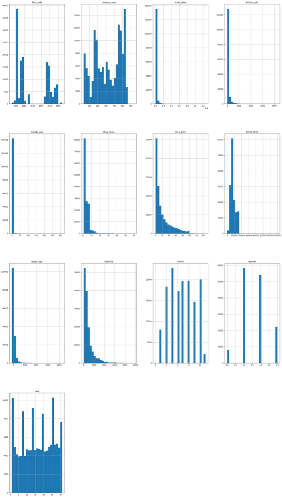

```python
Ticket.hist(bins = 25, figsize = (27,50))
plt.show()
```

[output not shown]

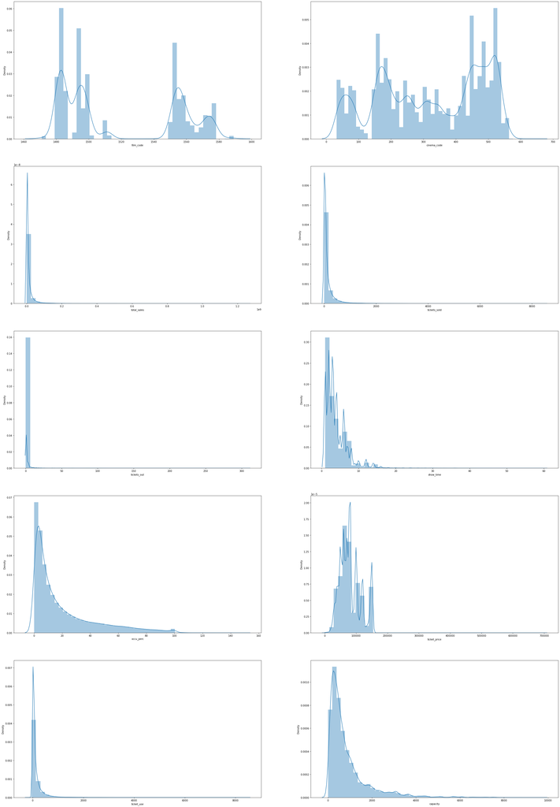

```python
fig, ax = plt.subplots(ncols = 2, nrows = 5, figsize = (40, 60))
index = 0
ax = ax.flatten()

for col, value in Ticket.items():
    if col != 'type':
        sns.distplot(value, ax = ax[index])
        index += 1
plt.tight_layout(pad = 0.5, w_pad = 0.7, h_pad = 5.0)
plt.show()
```

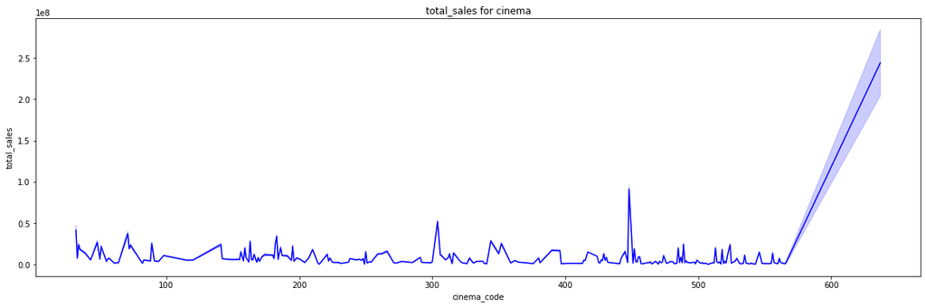

```python
plt.figure(figsize = (20,6))
sns.lineplot(data=Ticket, x="cinema_code", y="total_sales" , color = 'blue')
plt.title('total_sales for cinema')
```

#### Ticket price by cinema

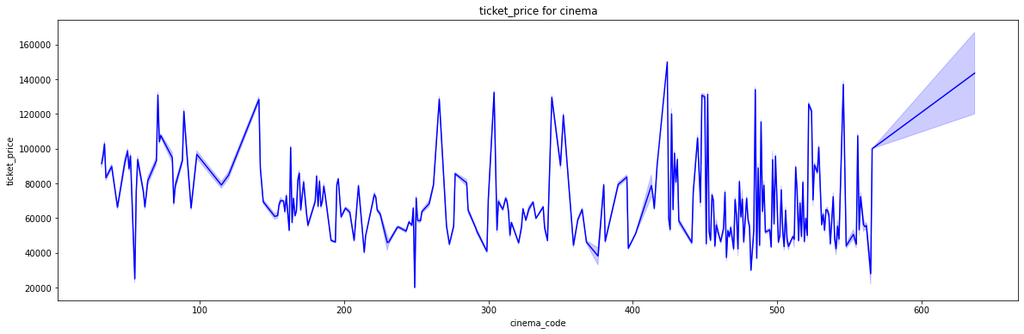

```python
plt.figure(figsize = (20,6))
sns.lineplot(data=Ticket, x="cinema_code", y="ticket_price" , color = 'blue')
plt.title('ticket_price for cinema')
```

#### Total Sales per date

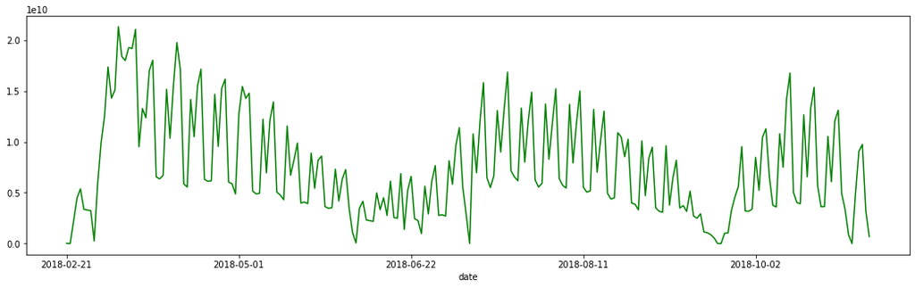

```python
Ticket.groupby('date')['total_sales'].sum().plot(figsize=(18, 5), color='green')
```

#### Ticket Price per date

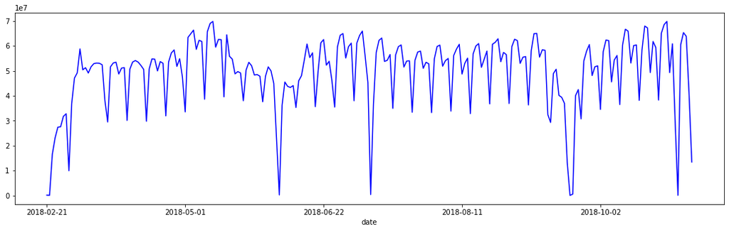

```python
Ticket.groupby('date')['ticket_price'].sum().plot(figsize=(18, 5), color='blue')
```

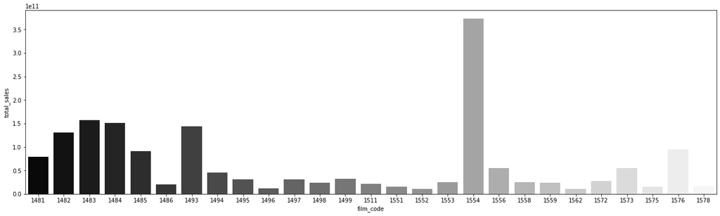

```python
fg = Ticket.groupby('film_code', as_index=False)['total_sales'].sum()
fg = fg[fg.total_sales > 9.000000e+09]
plt.figure(figsize=(22, 6))
sns.barplot(data=fg, x='film_code', y='total_sales', palette='gray')
```

```python
Ticket.total_sales.describe()
```

```
count    1.425240e+05
mean     1.234728e+07
std      3.065486e+07
min      2.000000e+04
25%      1.260000e+06
50%      3.720000e+06
75%      1.110000e+07
max      1.262820e+09
Name: total_sales, dtype: float64
```

```python
Ticket.ticket_price.describe()
```

```
count    142524.000000
mean      81234.599886
std       33236.599278
min         483.870968
25%       60000.000000
50%       79454.235180
75%      100000.000000
max      700000.000000
Name: ticket_price, dtype: float64
```

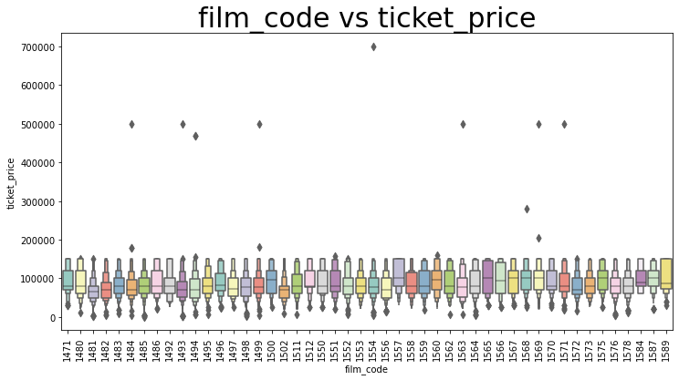

```python
plt.figure(figsize=(12,6))
sns.boxenplot(Ticket['film_code'], Ticket['ticket_price'], palette='Set3')
plt.title('film_code vs ticket_price', size=30)
plt.xticks(rotation=90)
plt.show()
```

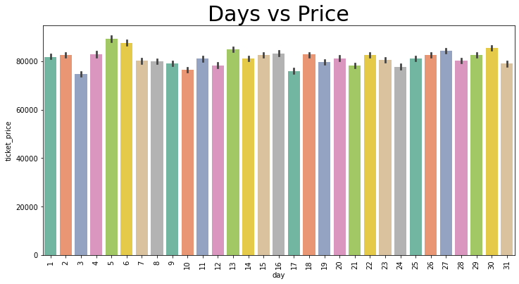

```python
plt.figure(figsize=(12,6))
sns.barplot(Ticket['day'], df['ticket_price'], palette='Set2')
plt.title('Days vs Price', size=30)
plt.xticks(rotation=90)
plt.show()
```

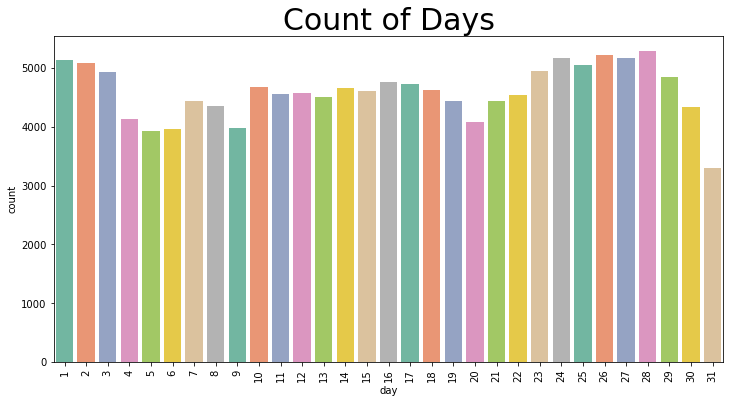

```python
plt.figure(figsize=(12,6))
sns.countplot(Ticket['day'], palette='Set2')
plt.title('Count of Days', size=30)
plt.xticks(rotation=90)
plt.show()
```

```python
Ticket['month'] = Ticket['month'].map({
    1:'JAN',
    2:'FEB',
    3:'MAR',
    4:'APR',
    5:'MAY',
    6:'JUN',
    7:'JUL',
    8:'AUG',
    9:'SEP',
    10:'OCT',
    11:'NOV',
    12:'DEC'
})
```

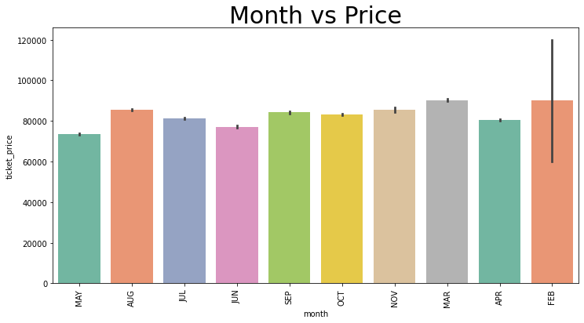

```python
plt.figure(figsize=(12,6))
sns.barplot(Ticket['month'], Ticket['ticket_price'], palette='Set2')
plt.title('Month vs Price', size=30)
plt.xticks(rotation=90)
plt.show()
```

### removing the irrelevant columns

```python
cols_to_drop = ["occu_perc","capacity","date"]
df = Ticket.drop(columns=cols_to_drop,axis=1)
```

[figure not shown]

```python
plt.figure(figsize = (15,5))
sns.barplot(x = 'ticket_price', y = 'total_sales', data =df)
plt.show()
```

#### way of checking linearity is in below cell

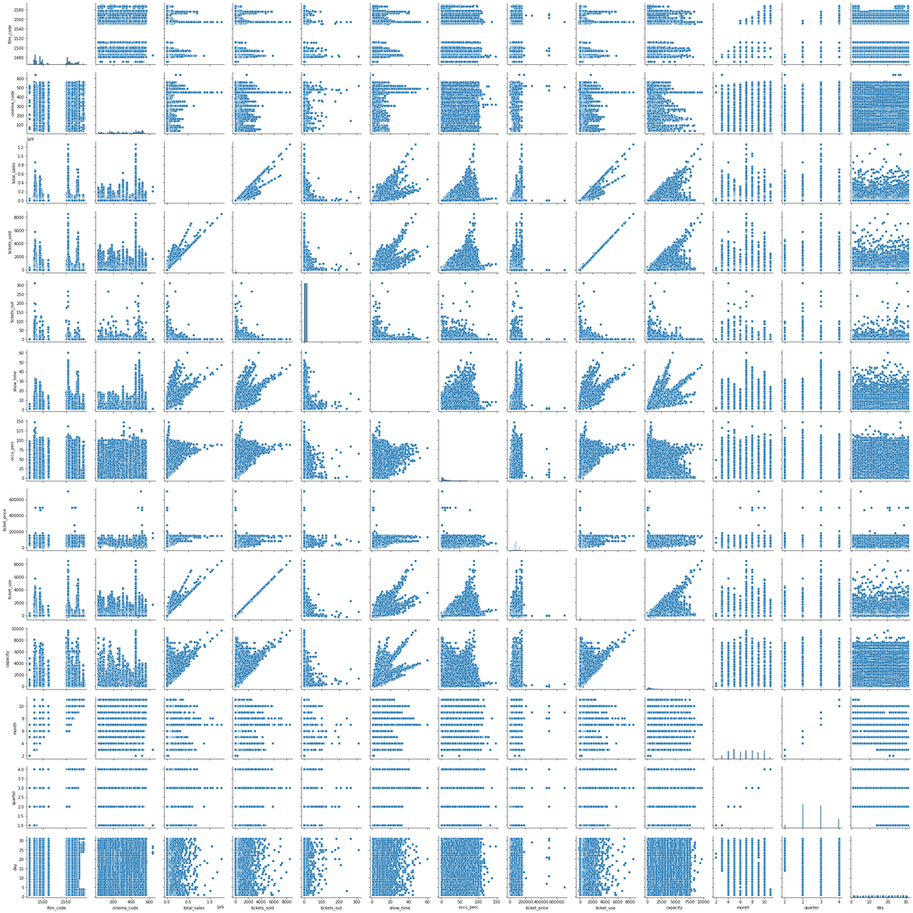

```python
# paiwise scatter plot
plt.figure(figsize=(20, 10))
sns.pairplot(Ticket)
```

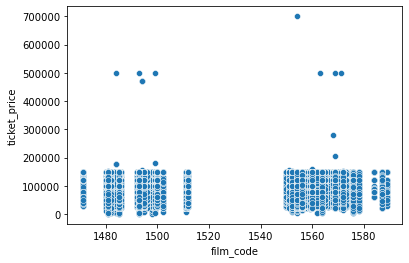

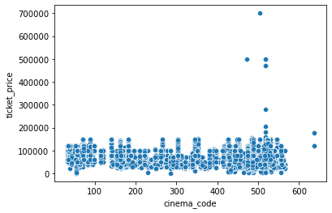

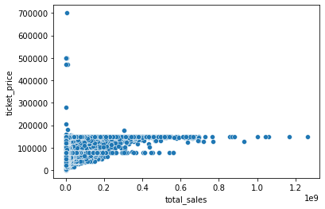

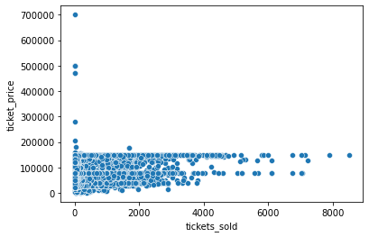

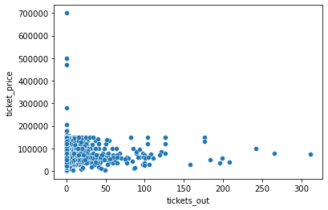

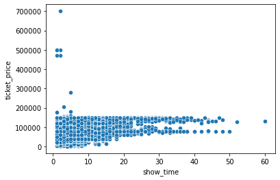

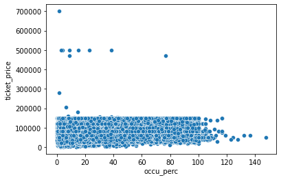

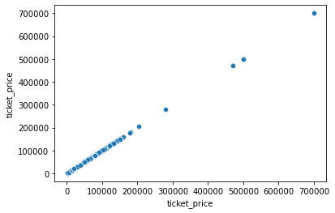

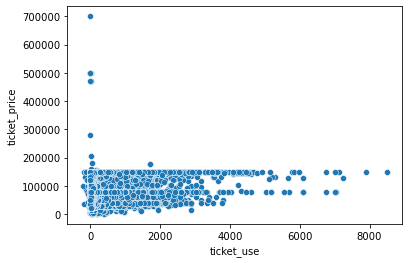

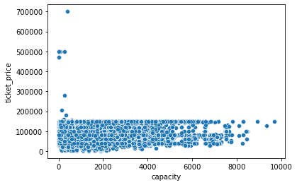

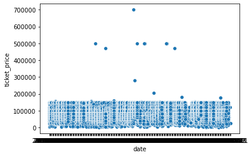

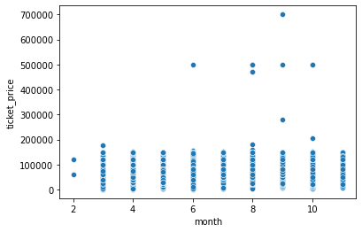

[2 more figures not shown]

```python
#to check price has linear relation or not with Indep. var's

for i, col in enumerate (Ticket.columns):
    plt.figure(i)
    sns.scatterplot(x=Ticket[col],y=df['ticket_price'])
```

- variables either don't have a relation with ticket price or relationship isn't strong.

```python
Ticket.corr()
```

[output not shown]